# AMR Data Visualization in R

# 7 Visualization 3: Box Plot — Comparing Distributions Across Groups

**When to use a box plot in AMR surveillance**

Box plots are useful when you want to compare the **spread and central tendency** of MIC values across multiple groups at once — such as comparing MIC distributions across different wards, different time periods, or different specimen types.

A single histogram shows you one group. A box plot shows you many groups side by side.

**Reading a box plot:**

- The **line inside the box** = median (middle value)
- The **box edges** = Q1 (25th percentile) and Q3 (75th percentile)
- The **whiskers** extend to 1.5× the interquartile range
- **Dots beyond the whiskers** = outliers (unusually high or low values)

## 7.1 Prepare data: MIC by ward

```r
# ── Filter to K. pneumoniae ciprofloxacin for box plot ───────────────────
kp_cip_mic <- mic_data %>%
  filter(
    organism   == "K. pneumoniae",
    antibiotic == "Ciprofloxacin"
  ) %>%
  mutate(
    mic_log2 = log2(mic_mg_l),
    ward     = factor(ward,
                      levels = c("ICU","SUR","MED","PED","OBS"))
  )

# How many isolates per ward?
kp_cip_mic %>%
  count(ward, name = "n") %>%
  kable(caption = "Table 3. K. pneumoniae isolates by ward") %>%
  kable_styling(bootstrap_options = "striped", full_width = FALSE)
```

Table 3. K. pneumoniae isolates by ward

| ward | n |
| --- | --- |
| ICU | 8 |
| SUR | 10 |
| MED | 9 |
| OBS | 5 |

## 7.2 Create the box plot

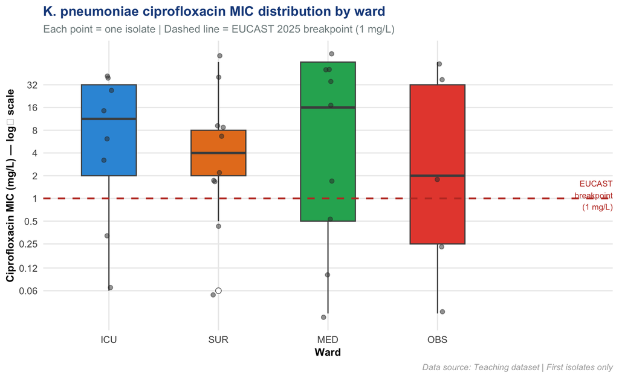

```r
# EUCAST CIP breakpoint for K. pneumoniae: S ≤1, R >1
bp_cip_log2 <- log2(1)

p_box <- ggplot(
  kp_cip_mic,
  aes(x    = ward,
      y    = mic_log2,
      fill = ward)
) +

  # The box plots
  geom_boxplot(
    width         = 0.5,
    colour        = "grey30",
    outlier.shape = 21,          # outlier points as open circles
    outlier.size  = 2.5,
    outlier.fill  = "white",
    outlier.colour= "grey40"
  ) +

  # Overlay individual data points (jittered so they don't overlap)
  geom_jitter(
    width  = 0.05,
    alpha  = 0.5,
    size   = 1.8,
    colour = "grey20"
  ) +

  # Breakpoint reference line
  geom_hline(
    yintercept = bp_cip_log2,
    linetype   = "dashed",
    colour     = "#c0392b",
    linewidth  = 0.9
  ) +
  annotate(
    "text", x = 5.6, y = bp_cip_log2 + 0.15,
    label = "EUCAST\nbreakpoint\n(1 mg/L)",
    hjust = 1, size = 3, colour = "#c0392b"
  ) +

  # Ward colours: one colour per ward
  scale_fill_manual(
    values = c("ICU" = "#3498db", "SUR" = "#e67e22",
               "MED" = "#27ae60", "PED" = "#9b59b6",
               "OBS" = "#e74c3c"),
    guide  = "none"   # legend not needed — wards labelled on x-axis
  ) +

  # y-axis: show real MIC values
  scale_y_continuous(
    breaks = log2(c(0.06, 0.12, 0.25, 0.5, 1, 2, 4, 8, 16, 32)),
    labels = c("0.06","0.12","0.25","0.5","1","2","4","8","16","32")
  ) +

  labs(
    title    = "K. pneumoniae ciprofloxacin MIC distribution by ward",
    subtitle = "Each point = one isolate | Dashed line = EUCAST 2025 breakpoint (1 mg/L)",
    x        = "Ward",
    y        = "Ciprofloxacin MIC (mg/L) — log₂ scale",
    caption  = "Data source: Teaching dataset | First isolates only"
  )

p_box
```

**Interpreting this box plot**

**Action:** Wards with high median MICs should have targeted stewardship reviews and tighter infection control measures.

# 8 Visualization 4: Scatter Plot — Trends Over Time and Correlations

Scatter plots in AMR surveillance are used for two distinct purposes:

1. **Trend over time** — showing how resistance % changes across quarterly periods
2. **Correlation** — showing whether antibiotic consumption is associated with rising resistance

## 8.1 4.1 Import trend and consumption data

```r
# ── Import pre-aggregated quarterly resistance data ───────────────────────
quarterly_r <- read_excel(excel_file, sheet = "Quarterly_R") %>%
  clean_names()

# ── Import consumption data ───────────────────────────────────────────────
consumption <- read_excel(excel_file, sheet = "Consumption") %>%
  clean_names()

head(quarterly_r)
```

| quarter | time_id | kp_cip | kp_mem | kp_ctx | kp_gen | ec_amp | ec_ctx | ec_cip | ec_sxt | sa_oxa | sa_gen | sa_cip | pa_mem | pa_cip | ab_mem | ab_cip | ab_col |
| --- | --- | --- | --- | --- | --- | --- | --- | --- | --- | --- | --- | --- | --- | --- | --- | --- | --- |
| Q1-2022 | 1 | 72.5 | 18.2 | 65.4 | 68.9 | 48.3 | 22.1 | 34.6 | 40.2 | 38.5 | 32.1 | 35.8 | 55.6 | 78.4 | 88.9 | 95.2 | 22.5 |
| Q2-2022 | 2 | 75.1 | 22.4 | 68.2 | 70.3 | 52.6 | 25.8 | 38.9 | 44.5 | 42.1 | 36.4 | 39.2 | 60.3 | 82.1 | 90.5 | 96.8 | 28.4 |
| Q3-2022 | 3 | 78.4 | 26.8 | 72.1 | 74.6 | 56.9 | 29.2 | 42.5 | 48.3 | 46.8 | 40.2 | 43.6 | 64.9 | 85.6 | 92.8 | 97.4 | 32.1 |
| Q4-2022 | 4 | 82.3 | 31.5 | 76.5 | 78.2 | 61.4 | 33.6 | 47.1 | 52.8 | 51.2 | 44.8 | 48.3 | 70.2 | 89.3 | 95.1 | 98.6 | 38.5 |

## 8.2 4.2 Trend scatter plot: Resistance over time

```r
# ── Prepare the trend data ────────────────────────────────────────────────
# We will plot K. pneumoniae ciprofloxacin resistance (kp_cip) over time

kp_trend <- quarterly_r %>%
  dplyr:: select(quarter, time_id, pct_r = kp_cip) %>%
  mutate(
    quarter = factor(quarter, levels = c("Q1-2022","Q2-2022",
                                         "Q3-2022","Q4-2022"))
  )

# ── Fit a linear regression model ────────────────────────────────────────
model <- lm(pct_r ~ time_id, data = kp_trend)
summary(model)
```

```
##
## Call:
## lm(formula = pct_r ~ time_id, data = kp_trend)
##
## Residuals:
##     1     2     3     4
##  0.33 -0.34 -0.31  0.32
##
## Coefficients:
##             Estimate Std. Error t value Pr(>|t|)
## (Intercept)  68.9000     0.5632   122.3 6.68e-05 ***
## time_id       3.2700     0.2057    15.9  0.00393 **
## ---
## Signif. codes:  0 '***' 0.001 '**' 0.01 '*' 0.05 '.' 0.1 ' ' 1
##
## Residual standard error: 0.4599 on 2 degrees of freedom
## Multiple R-squared:  0.9922, Adjusted R-squared:  0.9882
## F-statistic: 252.8 on 1 and 2 DF,  p-value: 0.003933
```

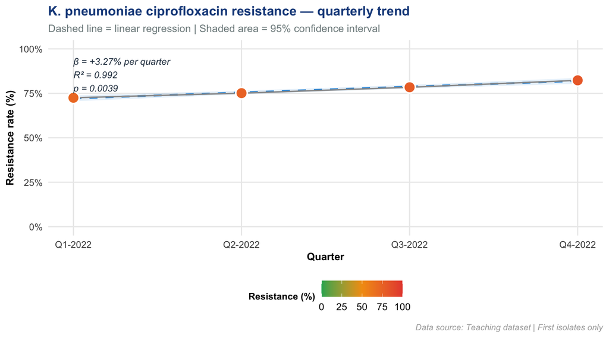

```r
# Extract key statistics for the annotation
slope   <- round(coef(model)[2], 2)
r2      <- round(summary(model)$r.squared, 3)
p_value <- round(coef(summary(model))[2, 4], 4)

# Create prediction data for the regression line
pred_df <- data.frame(time_id = seq(1, 4, length.out = 50))
preds   <- predict(model, newdata = pred_df, interval = "confidence")
pred_df <- cbind(pred_df, preds)

# ── Build the scatter plot ────────────────────────────────────────────────
p_scatter <- ggplot(kp_trend, aes(x = time_id, y = pct_r)) +

  # Confidence interval ribbon (shaded area around regression line)
  geom_ribbon(
    data = pred_df,
    aes(x = time_id, ymin = lwr, ymax = upr),
    fill  = "#3498db", alpha = 0.12,
    inherit.aes = FALSE
  ) +

  # Regression line
  geom_line(
    data = pred_df,
    aes(x = time_id, y = fit),
    colour    = "#3498db",
    linetype  = "dashed",
    linewidth = 1,
    inherit.aes = FALSE
  ) +

  # Connecting line between points
  geom_line(colour = "grey60", linewidth = 0.7) +

  # Data points — coloured by resistance level
  geom_point(
    aes(fill = pct_r),
    shape = 21, size = 5,
    colour = "white", stroke = 1.2
  ) +

  # Colour scale: green → amber → red
  scale_fill_gradientn(
    colours = c("#27ae60", "#f39c12", "#e74c3c"),
    values  = rescale(c(0, 50, 100)),
    limits  = c(0, 100),
    name    = "Resistance (%)"
  ) +

  # Quarter labels on x-axis
  scale_x_continuous(
    breaks = 1:4,
    labels = levels(kp_trend$quarter)
  ) +

  scale_y_continuous(
    limits = c(0, 100),
    labels = function(x) paste0(x, "%")
  ) +

  # Regression equation annotation
  annotate(
    "text",
    x = 1, y = 95,
    label = paste0(
      "β = +", slope, "% per quarter\n",
      "R² = ", r2, "\n",
      "p = ", p_value
    ),
    hjust  = 0, vjust = 1,
    size   = 3.5, colour = "#2c3e50",
    fontface = "italic"
  ) +

  labs(
    title    = "K. pneumoniae ciprofloxacin resistance — quarterly trend",
    subtitle = "Dashed line = linear regression | Shaded area = 95% confidence interval",
    x        = "Quarter",
    y        = "Resistance rate (%)",
    caption  = "Data source: Teaching dataset | First isolates only"
  )

p_scatter
```

**Interpreting the trend plot**

- **Beta (β):** The slope of the regression line, in units of “% change per quarter.” A positive β (e.g., +3.2%) means resistance is **rising** each quarter.
- **R²:** How well the time variable explains the variation in resistance. R² = 0.95 means 95% of the variation in resistance is explained by time — a strong trend.
- **p-value:** Tests whether the slope is statistically significantly different from zero. p < 0.05 means the trend is unlikely to be due to chance alone.

**Important limitation:** With only 4 time points, the statistical power is low. Even a significant p-value should be interpreted cautiously with so few data points. Always note this limitation when reporting.

## 8.3 4.3 Correlation: Consumption vs Resistance

```r
# ── Summarise ciprofloxacin consumption by quarter ────────────────────────
cip_consumption <- consumption %>%
  filter(str_detect(drug_name, "Cipro|cipro")) %>%
  group_by(quarter) %>%
  summarise(
    cip_ddd_1000pd = round(sum(ddd_dispensed) / sum(patient_days) * 1000, 1),
    .groups = "drop"
  )

# Join with resistance data
corr_df <- left_join(
  cip_consumption,
  quarterly_r %>% dplyr::select(quarter, kp_cip),
  by = "quarter"
) %>%
  filter(!is.na(kp_cip))

# Pearson correlation
cor_test <- cor.test(corr_df$cip_ddd_1000pd, corr_df$kp_cip, method = "pearson")
cat(sprintf("Pearson r = %.3f | p = %.4f\n",
            cor_test$estimate, cor_test$p.value))
```

```
## Pearson r = 0.861 | p = 0.1394
```

[output not shown]

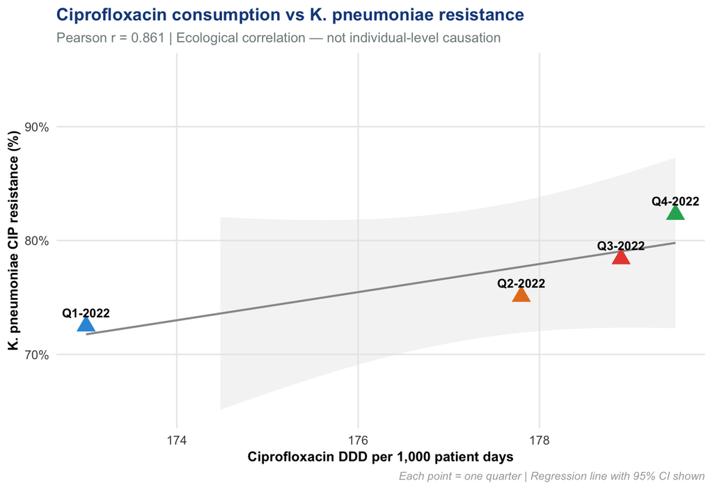

```r
# ── Scatter: DDD vs resistance ────────────────────────────────────────────
p_corr <- ggplot(corr_df,
                 aes(x = cip_ddd_1000pd, y = kp_cip,
                     label = quarter)) +

  geom_smooth(method = "lm", se = TRUE,
              colour = "grey60", fill = "grey90",
              linewidth = 0.8) +

  geom_point(aes(colour = quarter), size = 5, shape = 17) +

  geom_text(vjust = -1, hjust = 0.5, size = 3.5, fontface = "bold") +

  scale_colour_manual(
    values = c("Q1-2022" = "#3498db", "Q2-2022" = "#e67e22",
               "Q3-2022" = "#e74c3c", "Q4-2022" = "#27ae60"),
    guide = "none"
  ) +

  scale_y_continuous(limits = c(65, 95),
                     labels = function(x) paste0(x, "%")) +

  labs(
    title    = "Ciprofloxacin consumption vs K. pneumoniae resistance",
    subtitle = paste0("Pearson r = ", round(cor_test$estimate, 3),
                      " | Ecological correlation — not individual-level causation"),
    x        = "Ciprofloxacin DDD per 1,000 patient days",
    y        = "K. pneumoniae CIP resistance (%)",
    caption  = "Each point = one quarter | Regression line with 95% CI shown"
  )

p_corr
```

**The Ecological Fallacy — a critical warning**

- We cannot say that *patients who received ciprofloxacin* are more likely to become resistant
- Many other factors (clonal outbreak, patient mix, infection control) drive resistance
- The correlation may be spurious, especially with only 4 quarterly data points

Always add this caveat when reporting consumption-resistance correlations.

# 9 Visualization 5: Heatmap — The Full Resistance Overview

**When to use a heatmap in AMR surveillance**

A heatmap is the **information-densest** AMR visualization. It shows resistance rates for many organism-antibiotic combinations at once using colour intensity.

It is the standard format for: - Annual antibiogram presentations to infection control committees - Hospital-level AMR reports to management - Quick identification of which organism-antibiotic combinations are in crisis

## 9.1 Calculate all resistance rates

```r
# ── Calculate resistance for all priority organism-antibiotic pairs ────────
# We build a helper function then call it for each pair

pairs <- list(
  list(org="Klebsiella pneumoniae",   ab="cip"), list(org="Klebsiella pneumoniae",   ab="mem"),
  list(org="Klebsiella pneumoniae",   ab="ctx"), list(org="Klebsiella pneumoniae",   ab="gen"),
  list(org="Escherichia coli",        ab="amp"), list(org="Escherichia coli",        ab="ctx"),
  list(org="Escherichia coli",        ab="cip"), list(org="Escherichia coli",        ab="sxt"),
  list(org="Staphylococcus aureus",   ab="oxa"), list(org="Staphylococcus aureus",   ab="gen"),
  list(org="Staphylococcus aureus",   ab="cip"),
  list(org="Pseudomonas aeruginosa",  ab="mem"), list(org="Pseudomonas aeruginosa",  ab="cip"),
  list(org="Acinetobacter baumannii", ab="mem"), list(org="Acinetobacter baumannii", ab="cip"),
  list(org="Acinetobacter baumannii", ab="col")
)

all_resist <- bind_rows(lapply(pairs, function(p) {
  calc_resistance_ci(clean_data, p$org, p$ab)
}))

# Short organism names
all_resist <- all_resist %>%
  mutate(
    org_short = case_when(
      organism == "Klebsiella pneumoniae"   ~ "K. pneumoniae",
      organism == "Escherichia coli"        ~ "E. coli",
      organism == "Staphylococcus aureus"   ~ "S. aureus",
      organism == "Pseudomonas aeruginosa"  ~ "P. aeruginosa",
      organism == "Acinetobacter baumannii" ~ "A. baumannii",
      TRUE ~ organism
    ),
    # Flag small sample sizes
    label = paste0(pct_R, "%", ifelse(n_tested < 30, "*", ""))
  )

# Preview
all_resist %>%
  dplyr::select(org_short, antibiotic, n_tested, pct_R, label) %>%
  kable(caption = "Table 4. Resistance rates for heatmap") %>%
  kable_styling(bootstrap_options = "striped")
```

Table 4. Resistance rates for heatmap

| org_short | antibiotic | n_tested | pct_R | label |
| --- | --- | --- | --- | --- |
| K. pneumoniae | CIP | 33 | 36.4 | 36.4% |
| K. pneumoniae | MEM | 33 | 33.3 | 33.3% |
| K. pneumoniae | CTX | 33 | 42.4 | 42.4% |
| K. pneumoniae | GEN | 33 | 36.4 | 36.4% |
| E. coli | AMP | 43 | 32.6 | 32.6% |
| E. coli | CTX | 43 | 30.2 | 30.2% |
| E. coli | CIP | 43 | 41.9 | 41.9% |
| E. coli | SXT | 43 | 25.6 | 25.6% |
| S. aureus | OXA | 22 | 36.4 | 36.4%* |
| S. aureus | GEN | 22 | 36.4 | 36.4%* |
| S. aureus | CIP | 22 | 31.8 | 31.8%* |
| P. aeruginosa | MEM | 11 | 27.3 | 27.3%* |
| P. aeruginosa | CIP | 11 | 54.5 | 54.5%* |
| A. baumannii | MEM | 17 | 52.9 | 52.9%* |
| A. baumannii | CIP | 17 | 52.9 | 52.9%* |
| A. baumannii | COL | 17 | 29.4 | 29.4%* |

## 9.2 Create the heatmap

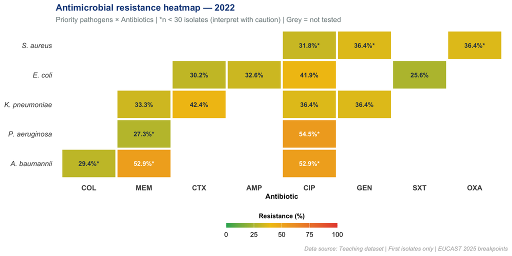

```r
# ── Order organisms by clinical priority ──────────────────────────────────
org_order <- c("A. baumannii","P. aeruginosa","K. pneumoniae",
                "E. coli","S. aureus")
ab_order  <- c("COL","MEM","CTX","AMP","CIP","GEN","SXT","OXA")

all_resist <- all_resist %>%
  mutate(
    org_short  = factor(org_short,  levels = org_order),
    antibiotic = factor(antibiotic, levels = ab_order)
  )

p_heat <- ggplot(
  all_resist,
  aes(x = antibiotic, y = org_short, fill = pct_R)
) +

  # Tiles — white lines between tiles act as grid lines
  geom_tile(colour = "white", linewidth = 1.5) +

  # Text label inside each tile
  geom_text(
    aes(label = label,
        colour = pct_R > 50),   # white text on dark tiles, dark on light
    size      = 3.5,
    fontface  = "bold"
  ) +

  # Colour scale: green → amber → red
  scale_fill_gradientn(
    colours   = c("#27ae60", "#f1c40f", "#e74c3c"),
    values    = rescale(c(0, 40, 100)),
    limits    = c(0, 100),
    na.value  = "grey85",
    name      = "Resistance (%)",
    guide     = guide_colourbar(barwidth = 12, barheight = 0.5,
                                title.position = "top",
                                title.hjust    = 0.5)
  ) +

  # Text colour: white on high-resistance tiles, dark on low
  scale_colour_manual(values = c("TRUE" = "white", "FALSE" = "#2c3e50"),
                      guide = "none") +

  labs(
    title    = "Antimicrobial resistance heatmap — 2022",
    subtitle = "Priority pathogens × Antibiotics | *n < 30 isolates (interpret with caution) | Grey = not tested",
    x        = "Antibiotic",
    y        = NULL,
    caption  = "Data source: Teaching dataset | First isolates only | EUCAST 2025 breakpoints"
  ) +

  theme(
    axis.text.y     = element_text(face = "italic", size = 11),
    axis.text.x     = element_text(face = "bold", size = 11),
    legend.position = "bottom",
    panel.grid      = element_blank()
  )

p_heat
```

**Reading the heatmap**

# 10 Combining Charts: Creating a Dashboard Figure

For reports and presentations, you often want to show multiple related charts together. The `patchwork` package makes this easy:

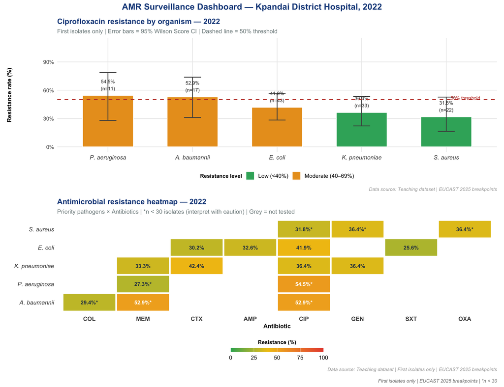

```r
# ── Combine the bar plot and heatmap into one figure ──────────────────────
combined <- (p_bar / p_heat) +
  plot_annotation(
    title   = "AMR Surveillance Dashboard — Kpandai District Hospital, 2022",
    caption = "First isolates only | EUCAST 2025 breakpoints | *n < 30",
    theme   = theme(
      plot.title   = element_text(size = 16, face = "bold",
                                   colour = "#1A4A8A", hjust = 0.5),
      plot.caption = element_text(size = 9, colour = "grey50")
    )
  ) +
  plot_layout(heights = c(1.2, 1))

combined
```

```r
# ── Save dashboard figure ─────────────────────────────────────────────────
ggsave(
  "AMR_Dashboard_2022.png",
  plot   = combined,
  width  = 13,
  height = 10,
  dpi    = 300
)
```

# 11 Putting It All Together: A Complete Reporting Workflow

```r
# ── COMPLETE WORKFLOW — COPY THIS FOR YOUR OWN HOSPITAL DATA ──────────────

# 1. Set your file path
my_file <- "path/to/your/data.xlsx"

# 2. Import
raw <- read_excel(my_file, sheet = "YourSheetName") %>% clean_names()

# 3. Clean
clean <- raw %>%
  filter(!is.na(patient_id)) %>%                          # remove blanks
  mutate(organism_std = str_to_title(str_trim(organism))) # standardise names

# 4. First isolate rule
analysis <- clean %>%
  arrange(patient_id, organism_std, collection_date) %>%
  group_by(patient_id, organism_std) %>%
  slice(1) %>%  # keep only the first row per group
  ungroup()

# 5. Calculate resistance
results <- calc_resistance_ci(analysis, "Klebsiella pneumoniae", "cip")

# 6. Plot
p <- ggplot(results, aes(x = antibiotic, y = pct_R, fill = pct_R)) +
  geom_col() + amr_theme

# 7. Save
ggsave("my_resistance_plot.png", plot = p, width = 8, height = 5, dpi = 300)
```

# 12 Session Information

It is good practice to include session information at the end of your R Markdown document. This records exactly which versions of R and each package were used — important for reproducibility.

[session information not shown]

**Next steps**

1. **Exercise :** Use this Rmd with your own hospital’s WHONET export. Follow the same cleaning steps.
2. Explore the `AMR` package in R — purpose-built for clinical microbiology data analysis with built-in EUCAST/CLSI breakpoints.

*AMR Surveillance Training Programme | Data Visualization in R | Version 1.0, 2026*